# Statistical inference with the GSS data

## Setup

### Load packages

```r
library(ggplot2)
library(dplyr)
library(statsr)
```

### Load data

```r
load("gss.Rdata")
```

## Part 1: Data

For more than four decades, the General Social Survey (GSS) has studied the growing complexity of American society. It is the only full-probability, personal-interview survey designed to monitor changes in both social characteristics and attitudes currently being conducted in the United States. The basic GSS design is a repeated cross-sectional survey of a nationally representative sample of non-institutionalized adults who speak either English or Spanish. Subsampling of nonrespondents is done to limit survey costs while maintaining a nationally representative sample. Each GSS formally includes an A sample and a B sample. The preferred interview mode is inperson interviews; however, a few interviews will be done by telephone in the event that an inperson contact cannot be scheduled. Since there is random sampling in GSS surveys, there is no reason why their results cannot be generalized to the overall US population. However, since this is an observational study and not experimental, causality cannot be drawn from these results. There is also a small chance of non-response bias.

## Part 2: Research question

Before the advent of COVID-19, the American economy seemed to be flourishing. Unemployment numbers were down, the stock market was booming, and GDP was at an all time high. However, although the situation looked good on paper, the American people were suffering. Suicides and drug overdoses were also at an all-time high, and the average American life expectancy decreased 3 years in a row for the first time since 1920. The death rate from deaths of despair (deaths resulting from suicide, drug and alcohol poisoning, and alcoholic liver disease) have now outpaced lung cancer, stroke, and car crashes when adjusted for age, according to the CDC. Economists have theorized that this is due to automation. As machine labor replaces human labor in many areas of the economy, people are exiting the workforce, skewing unemployment numbers while losing their sense of purpose in life. Meanwhile, the economy maintains its progress. Suicide is viewed by many as an emotional reaction, perhaps to loss or as a result of depression, but usually not for financial reasons. For this inferential study, I will examine whether people’s attitudes on suicide have shifted when it comes to economic hardship.

*Research Question:* Have Americans increased their acceptance of suicide borne out of financial adversity between 1977 (the first year which had data on this question) and 2012?

## Part 3: Exploratory data analysis

In order to begin the EDA, I will first filter out all data that does not pertain to my research question, as not every year in this dataframe had data on this question.

```r
table(gss$suicide2, gss$year)
```

```
##
##       1972 1973 1974 1975 1976 1977 1978 1980 1982 1983 1984 1985 1986 1987
##   Yes    0    0    0    0    0  104   84    0  140  103    0  120   98    0
##   No     0    0    0    0    0 1402 1437    0 1679 1465    0 1384 1360    0
##
##       1988 1989 1990 1991 1993 1994 1996 1998 2000 2002 2004 2006 2008 2010
##   Yes   55   70   69   69   90  181  185  180  163   76  101  178  111  156
##   No   911  917  827  933  970 1758 1737 1653 1679  820  795 1795 1198 1250
##
##       2012
##   Yes  144
##   No  1127
```

```r
gss <- gss %>%
  filter(suicide2 != 0, !is.na(suicide2))

table(gss$suicide2, gss$year)
```

```
##
##       1977 1978 1982 1983 1985 1986 1988 1989 1990 1991 1993 1994 1996 1998
##   Yes  104   84  140  103  120   98   55   70   69   69   90  181  185  180
##   No  1402 1437 1679 1465 1384 1360  911  917  827  933  970 1758 1737 1653
##
##       2000 2002 2004 2006 2008 2010 2012
##   Yes  163   76  101  178  111  156  144
##   No  1679  820  795 1795 1198 1250 1127
```

Now that the data has been filtered, the proportion of Americans who answered ‘Yes’ to `suicide2` can be properly viewed on a summary table, grouped by `year`.

```r
gss %>%
  group_by(year) %>%
  summarise(prop = sum(suicide2 == 'Yes')/n())
```

```
## # A tibble: 21 x 2
##     year   prop
##    <int>  <dbl>
##  1  1977 0.0691
##  2  1978 0.0552
##  3  1982 0.0770
##  4  1983 0.0657
##  5  1985 0.0798
##  6  1986 0.0672
##  7  1988 0.0569
##  8  1989 0.0709
##  9  1990 0.0770
## 10  1991 0.0689
## # ... with 11 more rows
```

This summary does not give us a clear picture of the data, so I will use a line graph and scatterplot combination instead to examine any potential trends.

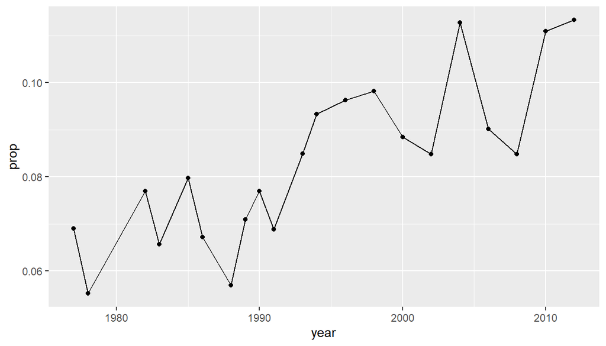

```r
yr_suicide <- gss %>%
  group_by(year) %>%
  summarise(prop = sum(suicide2 == 'Yes')/n())

ggplot(data = yr_suicide, aes(x = year, y = prop)) +
  geom_line() +
  geom_point()
```

As we can see, there is indeed an upward trend in the proportion of people answering “yes” to the question: Do you think a person has the right to end his or her own life if this person has gone bankrupt?. However, we do not yet know if this trend is statistically significant.

## Part 4: Inference

Since we will be comparing the proportions for two categorical variables (each with only 2 levels), we will be conducting a hypothesis test and determining a confidence interval for the difference in proportions.

### Part 4.1: Hypothesis test

A hypothesis test will determine the chance that the proportion of people answering “Yes” to `suicide2` would be greater than 0.1133 in 2012 if indeed the true proportion was 0.06906 as reported in 1977. We will be using a significance level of 0.05. Therefore, if we are given a p-value of less than 0.05, we will be rejecting our null hypotheses.

**Hypotheses**

*Null hypothesis:* The proportion of people who were accepting of suicide borne out of financial hardship was the same in 2012 as it was in 1977.

*Alternative hypothesis:* The proportion of people who were accepting of suicide borne out of financial hardship was greater in 2012 than it was in 1977.

**Conditions**

*Independence within groups* The GSS uses random sampling, so this condition is met.

*Independence between groups* The GSS interviews a different random sample every year, so there is no reason to believe the results from one year would be dependent on another.

*Sample Size/Skew* In order to find out if the success/failure condition is met, we must first determine the pooled proportion for our variable of interest. To do this, I will also filter out the dataframe “yr_suicide” to only include the years of 1977 and 2012.

```r
yr_suicide <- yr_suicide %>%
  filter(year == '1977'|year == '2012')
yr_suicide %>%
  summarise(pool_p = sum(prop)/n())
```

```
## # A tibble: 1 x 1
##   pool_p
##    <dbl>
## 1 0.0912
```

With a pooled proportion of about 0.0912, we now need to find the sample size for each year, then test for the success/failure condition.

```r
gss <- gss %>%
  filter(year == '1977'|year == '2012')
gss %>%
  group_by(year) %>%
  summarise(sucess = 0.0912*n(), failure = (1-0.0912)*n())
```

```
## # A tibble: 2 x 3
##    year sucess failure
##   <int>  <dbl>   <dbl>
## 1  1977   137.   1369.
## 2  2012   116.   1155.
```

Since the number of successes and failures are greater than 10 in both samples, this condition is met.

**Method**

We can now conduct a hypothesis test on our data to determine if we have enough evidence to reject the null hypothesis. Our significance level will be 5%.

```r
inference(y = suicide2, x = as.factor(year), data = gss, statistic = "proportion", type = "ht", null = 0,
          alternative = "greater", method = "theoretical", success = 'Yes', order(1977, 2012))
```

```
## Response variable: categorical (2 levels, success: Yes)
## Explanatory variable: categorical (2 levels)
## n_2012 = 1271, p_hat_2012 = 0.1133
## n_1977 = 1506, p_hat_1977 = 0.0691
## H0: p_2012 =  p_1977
## HA: p_2012 > p_1977
## z = 4.0727
## p_value = < 0.0001
```

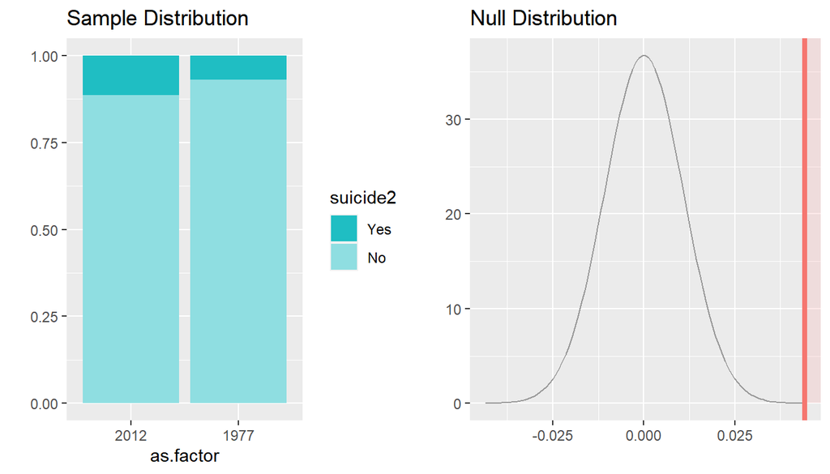

### Part 4.2: Confidence interval for proportions

Since the conditions for conducting a hypothesis test on two sample proportions are the same for determining a confidence interval between two sample proportions, there is no need to check the conditions again for this confidence interval. We will now calculate the confidence interval for the difference between the two sample proportions using a 95% confidence interval.

```r
inference(y = suicide2, x = as.factor(year), data = gss, statistic = 'proportion', type = 'ci', method = 'theoretical', success = 'Yes', order(1977, 2012))
```

```
## Response variable: categorical (2 levels, success: Yes)
## Explanatory variable: categorical (2 levels)
## n_2012 = 1271, p_hat_2012 = 0.1133
## n_1977 = 1506, p_hat_1977 = 0.0691
## 95% CI (2012 - 1977): (0.0226 , 0.0659)
```

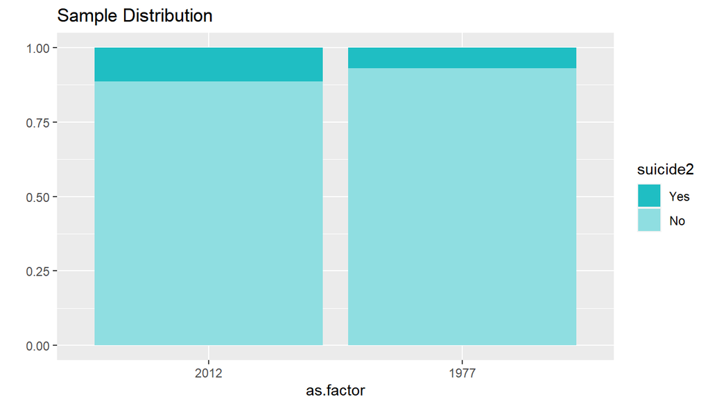

With the results of this confidence interval function, we are 95% confident that the proportion of Americans in 2012 who answered ‘Yes’ to `suicide2` was 2.26%-6.59% higher than the proportion of Americans in 1977 who answered ‘Yes to `suicide2`. This confidence interval agrees with the findings of our hypothesis test, with both results telling us that the difference between the proportion of people who answered ’Yes’ to `suicide2` in 1977 and 2012 was unlikely to be 0.

### Part 5: Results

Americans have increased their acceptance of suicide borne out of financial adversity between 1977 and 2012. In fact, we are 95% confident that 2.26%-6.59% more Americans between 1977 and 2012 would answer ‘Yes’ to the question: Do you think a person has the right to end his or her own life if this person has gone bankrupt?

### Part 6: Discussion

Due to the GSS being an observational study, there is no justification to draw causality in these results. However, it is worthy to note that these results correspond to an increase in the rate of deaths of despair in the United States. Further research will need to be conducted to determine a cause for these findings.